# Problem Set 4 Solutions

# Question 1 (40 points)

Consider a special case of the long-run risks model:
$$\begin{gather}
x_{t+1} = \rho x_{t} + \varphi_{e}\sigma e_{t+1} \\
g_{t+1} = \log\left(C_{t+1}/C_{t}\right) = \mu + x_{t} + \sigma
\eta_{t+1} \\
e_{t+1},\eta_{t+1} \overset{i.i.d.}{\sim} N(0,1) \\
\end{gather}$$

$\mu = 0.0015$, $\sigma = 0.0078$, $\rho = 0.979$, $\varphi_e = 0.044$, and $\varphi_d = 4.5$. Download real personal consumption expenditures data from the BEA for the period Jan 1999 – Mar 2018 and use the sum of non-durable and services as a monthly series for consumption (note: the Quandl code for the data is `BEA/T20806_M`). Estimate values for the latent state $\hat{\xi}_{t+1|t} = \hat{x}_{t+1|t}$ for each month using the Kalman filter. Write the recursions yourself (without using any `R` packages) and plot the forecasts of the latent states.

#### Solution:

```r
consumptionData = Quandl("BEA/T20806_M")
```

[output not shown]

# Question 2 (30 points)

Suppose that $r_1$, $r_2$, , $r_n$ are observations of a return series that follows the $AR(1)-GARCH(1,1)$ model:
$$\begin{align}
r_t & = \mu + \phi r_{t-1} + \sigma_t \varepsilon_t \\
\sigma_t^2 & = \alpha_0 + \alpha_1 \sigma_{t-1}^2 \varepsilon_{t-1}^2 + \beta_1 \sigma_{t-1}^2,
\end{align}$$

where $\varepsilon_t \stackrel{i.i.d.}{\sim} N(0,1)$. Derive the conditional log likelihood of the data.

#### Solution:

Letting $\Omega_t$ be the time $t$ information set, we know that $r_t|\Omega_{t-1} \sim N(\mu + \phi r_{t-1},\alpha_0 + \alpha_1 \sigma_{t-1}^2 \varepsilon_{t-1}^2 + \beta_1 \sigma_{t-1}^2)$. Thus, the conditional likelihood is
$$\begin{align}
L(\mu,\phi,\alpha_0,\alpha_1,\beta_1|r_1,\ldots,r_n) & = f(r_1,\ldots,r_n|\mu,\phi,\alpha_0,\alpha_1,\beta_1) \\
& = f(r_1|\mu,\phi,\alpha_0,\alpha_1,\beta_1) \prod_{t=2}^{n} f(r_t|r_{t-1},\mu,\phi,\alpha_0,\alpha_1,\beta_1) \\
& approx \prod_{t=2}^{n} \frac{1}{\sqrt{2\pi \alpha_0 + \alpha_1 \sigma_{t-1}^2 \varepsilon_{t-1}^2 + \beta_1 \sigma_{t-1}^2}} \exp\left\{-\frac{1}{2} \frac{(r_t-\mu - \phi r_{t-1})^2}{\alpha_0 + \alpha_1 \sigma_{t-1}^2 \varepsilon_{t-1}^2 + \beta_1 \sigma_{t-1}^2}\right\} \\
\Rightarrow \ell(\mu,\phi,\alpha_0,\alpha_1,\beta_1|r_1,\ldots,r_n) & \approx -\frac{n-1}{2}\log(2\pi) - \frac{1}{2}\sum_{t=2}^n \log(\alpha_0 + \alpha_1 \sigma_{t-1}^2 \varepsilon_{t-1}^2 + \beta_1 \sigma_{t-1}^2) - \frac{1}{2} \sum_{t=2}^n \frac{(r_t-\mu - \phi r_{t-1})^2}{\alpha_0 + \alpha_1 \sigma_{t-1}^2 \varepsilon_{t-1}^2 + \beta_1 \sigma_{t-1}^2}.
\end{align}$$

# Question 3 (30 points)

Consider the monthly returns of Intel stock from January 1973 to May 2018. Transform the returns into log returns. Build a GARCH model for the transformed series and compute 1-step to 5-step ahead volatility forecasts at the forecast origin May 2018. Plot your volatility estimates for the entire period, along with your forecasts.

#### Solution:

After importing the data and computing montly log returns, we can use the `fGarch` package to estimate a $GARCH(1,1)$ model:

```r
garchEst
```

```
Title:
 GARCH Modelling

Call:
 garchFit(data = logIntelRets)

Mean and Variance Equation:
 data ~ garch(1, 1)
<environment: 0x111180e60>
 [data = logIntelRets]

Conditional Distribution:
 norm

Coefficient(s):
        mu       omega      alpha1       beta1
9.0214e-03  9.9491e-05  5.8513e-02  9.3328e-01

Std. Errors:
 based on Hessian

Error Analysis:
        Estimate  Std. Error  t value Pr(>|t|)
mu     9.021e-03   4.354e-03    2.072 0.038264 *
omega  9.949e-05   1.050e-04    0.947 0.343560
alpha1 5.851e-02   1.700e-02    3.442 0.000577 ***
beta1  9.333e-01   2.062e-02   45.256  < 2e-16 ***
---
Signif. codes:  0 ‘***’ 0.001 ‘**’ 0.01 ‘*’ 0.05 ‘.’ 0.1 ‘ ’ 1

Log Likelihood:
 396.6278    normalized:  0.8641127

Description:
 Sat Jun 16 19:18:52 2018 by user:
```

The estimated volatility equation is
$$\begin{align}
\sigma_t^2 & = 0.00009949 + 0.05851 \varepsilon_{t-1}^2 + 0.9333 \sigma_{t-1}^2,
\end{align}$$

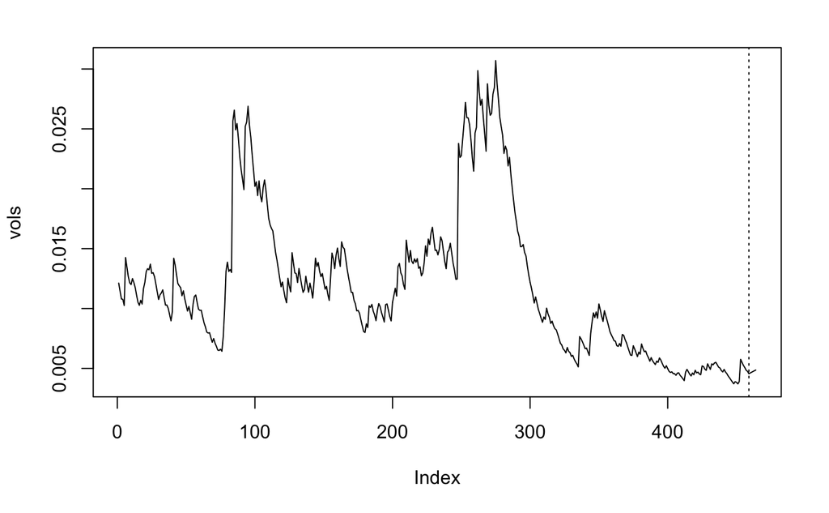